# CV and sparsity

Joyce Hsiao

2015-10-07

**Last updated:** 2015-10-09

**Code version:** 22d9bcfad1ca50f0fa3178ee558852c0a9b6886c

**Last updated:** 2015-10-14

**Code version:** ad00494d79195dafacf84a4ae0b08314007456b3

## Objective

Explore the relationship between coefficient of variation and sparsity.

As expected, a large coefficient of variation is associated with a large number of zero-count cells in a gene, an observation that is consistent with an important feature of the count data where the coefficient of variation is large for genes with low expression levels.

## Set up

```r
library("data.table")
library("dplyr")
library("limma")
library("edgeR")
library("ggplot2")
library("grid")
theme_set(theme_bw(base_size = 12))
source("functions.R")

## Knitr settings
library(knitr)
opts_knit$set(progress = TRUE, verbose = TRUE)
opts_chunk$set(message = FALSE, warning = FALSE, eval = TRUE,
               echo = TRUE)
```

## Prepare data

Input annotation of only QC-filtered single cells

```r
anno_qc <- read.table("../data/annotation-filter.txt", header = TRUE,
                   stringsAsFactors = FALSE)
head(anno_qc)
```

```
  individual replicate well      batch      sample_id
1    NA19098        r1  A01 NA19098.r1 NA19098.r1.A01
2    NA19098        r1  A02 NA19098.r1 NA19098.r1.A02
3    NA19098        r1  A04 NA19098.r1 NA19098.r1.A04
4    NA19098        r1  A05 NA19098.r1 NA19098.r1.A05
5    NA19098        r1  A06 NA19098.r1 NA19098.r1.A06
6    NA19098        r1  A07 NA19098.r1 NA19098.r1.A07
```

Input molecule counts that are filtered, transformed, and also processed to remove unwanted variation from batch effet. ERCC genes are also removed.

```r
molecules_qc <- read.table("../data/molecules-final.txt", header = TRUE, stringsAsFactors = FALSE)
```

## Compute coefficient of variation

Compute per batch coefficient of variation.

Include only genes with positive coefficient of variation. Some genes in this data may have zero coefficient of variation, because we include gene with more than 0 count across all cells.

```r
molecules_cv_batch <-
  lapply(1:length(unique(anno_qc$batch)), function(per_batch) {
        molecules_per_batch <- molecules_qc[ , unique(anno_qc$batch) == unique(anno_qc$batch)[per_batch] ]
        mean_per_gene <- apply(molecules_per_batch, 1, mean, na.rm = TRUE)
        sd_per_gene <- apply(molecules_per_batch, 1, sd, na.rm = TRUE)
        cv_per_gene <- data.frame(mean = mean_per_gene,
                                  sd = sd_per_gene,
                                  cv = sd_per_gene/mean_per_gene)
        rownames(cv_per_gene) <- rownames(molecules_qc)

        cv_per_gene <- cv_per_gene[rowSums(is.na(cv_per_gene)) == 0, ]
        cv_per_gene$batch <- unique(anno_qc$batch)[per_batch]
        return(cv_per_gene)
      })
names(molecules_cv_batch) <- unique(anno_qc$batch)

dim(molecules_cv_batch[[1]])
```

```
[1] 10483     4
```

## Sparsity

Import molecule count file before normlization.

```r
molecules_filter <- read.table("../data/molecules-filter.txt")

select_nonERCC <- grep("ERCC", rownames(molecules_filter), invert = TRUE)
molecules_ENSG <- molecules_filter[select_nonERCC, ]

stopifnot(dim(molecules_ENSG) == dim(molecules_qc))
```

Compute the proportion of zero count cells in each gene.

```r
molecules_sparse_batch <-
  lapply(1:length(unique(anno_qc$batch)), function(per_batch) {
        sparse_per_batch <- molecules_ENSG[ , unique(anno_qc$batch) == unique(anno_qc$batch)[per_batch] ]
        sparse_per_gene <- apply(sparse_per_batch, 1, function(x) {
                                  mean(x == 0)
                                })
        return(sparse_per_gene)
      })
names(molecules_sparse_batch) <- unique(anno_qc$batch)
str(molecules_sparse_batch[[1]])
```

```
 Named num [1:10483] 0.5846 0.2308 0.1385 0.0615 0.2923 ...
 - attr(*, "names")= chr [1:10483] "ENSG00000237683" "ENSG00000188976" "ENSG00000187608" "ENSG00000188157" ...
```

```r
str(molecules_sparse_batch[[2]])
```

```
 Named num [1:10483] 0.6 0.2308 0.1846 0.0615 0.2308 ...
 - attr(*, "names")= chr [1:10483] "ENSG00000237683" "ENSG00000188976" "ENSG00000187608" "ENSG00000188157" ...
```

Frequency of zero-count cell proportions.

```r
par(mfrow = c(3,3), mar = c(4,2,2,3))
for (per_batch in 1:length(unique(anno_qc$batch))) {
  hist( molecules_sparse_batch[[per_batch]],
        main = unique(anno_qc$batch)[per_batch], breaks = 100,
        ylim = c(0, 3000), xlim = c(0, 1),
        xlab = "No. of zero-count cells")
}
```

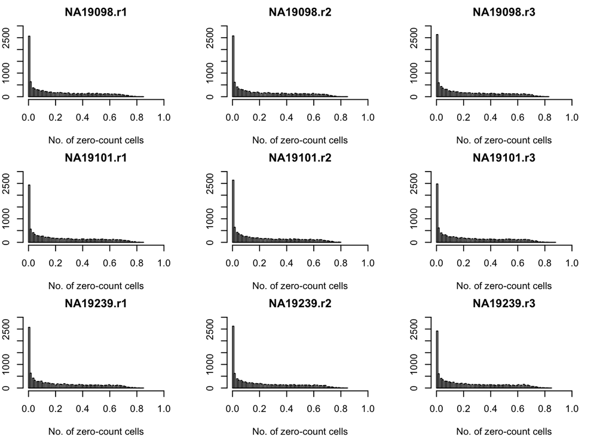

[figure not shown]

## CV and sparsity

```r
require(broman)
require(scales)
crayons <- brocolors("crayon")
par(mfrow = c(3,3), mar = c(4,2,2,3))
for (per_batch in 1:length(unique(anno_qc$batch))) {
  df_xy <- data.frame(x = molecules_sparse_batch[[per_batch]],
                      y = molecules_cv_batch[[per_batch]]$cv)
  plot(df_xy,
       xlab = "Proportion of zero-count cells",
       ylab = "CV",
       xlim = c(0, 1), ylim = c(0, 1),
       main = unique(anno_qc$batch)[per_batch],
       cex = .6, pch = 16, col = alpha(crayons["Outer Space"], .8))
  loess_fit <- loess(y ~ x, df_xy)
  x_seq <- with(df_xy, seq(min(x), max(x), by = .01))
  lines(x_seq,
        predict(loess_fit, x_seq),
        col = crayons["Outrageous Orange"],
        lwd = 1)
}
```

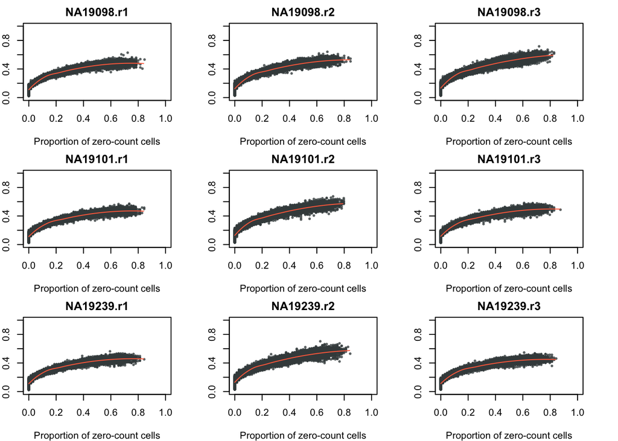

[figure not shown]